# Homework_7

Victor Dalgaard

2022-11-07

# Goal

I want to be able to analyse the data on police shootings from 2013-2020 (july 2020) that were through 2020 nicely collated on summarised on https://killedbypolice.net/kbp2020. That domain, however, no longer exists - or rather - has been rerouted to https://robarguns.com/kbp2020 and so we will be using the *archived version* of the site at http://web.archive.org/web/20200502072010/https://killedbypolice.net/kbp2020/.

```r
library(tidyverse)
library(ggplot2)
library(ggridges)
library(tidyr)
library(dplyr)
```

# Data

I scrape and clean the data following the instructions on Adelas Github: https://github.com/Digital-Methods-HASS/WebscrapingPoliceKillings

Then I import the data as a .csv

```r
data <- read_csv("data/policekillings2013-2020.csv")
```

```
## ──────────────────────────────────────────────────────── Delimiter: "," chr
## (6): Name, Gender, Race, State, Method, Source dbl (3): ...1, Age, Year date
## (1): Date
```

# Analyzing the data

## Age

I made a plot to explore the age at which the people died at.

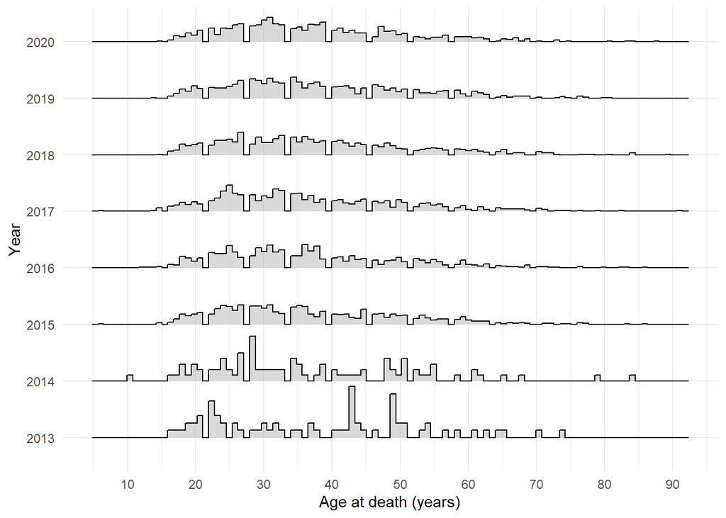

```r
data %>%
  ggplot(aes(x = Age,
             y = factor(Year),
             fill = Age)) +
  geom_density_ridges(alpha = 0.5,
                      scale = 0.9,
                      stat="binline",
                      bins=100)  +
  scale_x_continuous(breaks = seq(0, 100, 10),
                     labels = seq(0, 100, 10)) +
  xlab("Age at death (years)") +
  ylab("Year") +
  theme_minimal()
```

The age at which people are most likely to be killed by police officers is in the late twenties and early thirties, and this trend has not changed much over time. However, with time the age is centering more around the thirties rather than the twenties.

## Race

I made a plot to explore which races were most represented in the data.

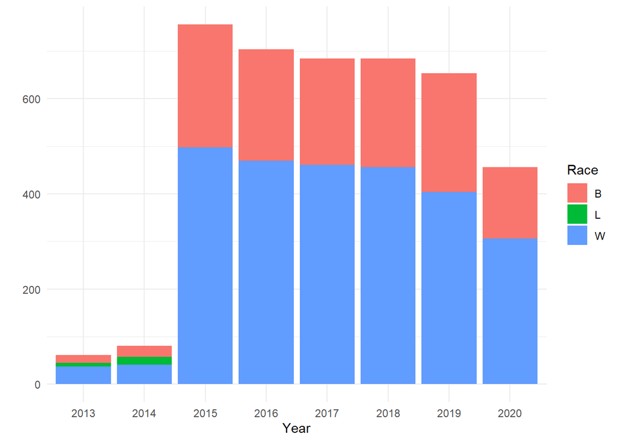

```r
data %>%
  filter(Race %in% c("B", "W", "L")) %>%
  filter(!is.na(Year)) %>%
  ggplot(aes(x = factor(Year),
             fill = Race)) +
  geom_bar()  +
  xlab("Year") +
  ylab("") +
  theme_minimal()
```

Of the three ethnic groups that make up most of the deaths, White people tend to be killed the most, Black people second most, and Latino is barely represented in the statistics.

## Gender

I made a plot to explore the gender distribution.

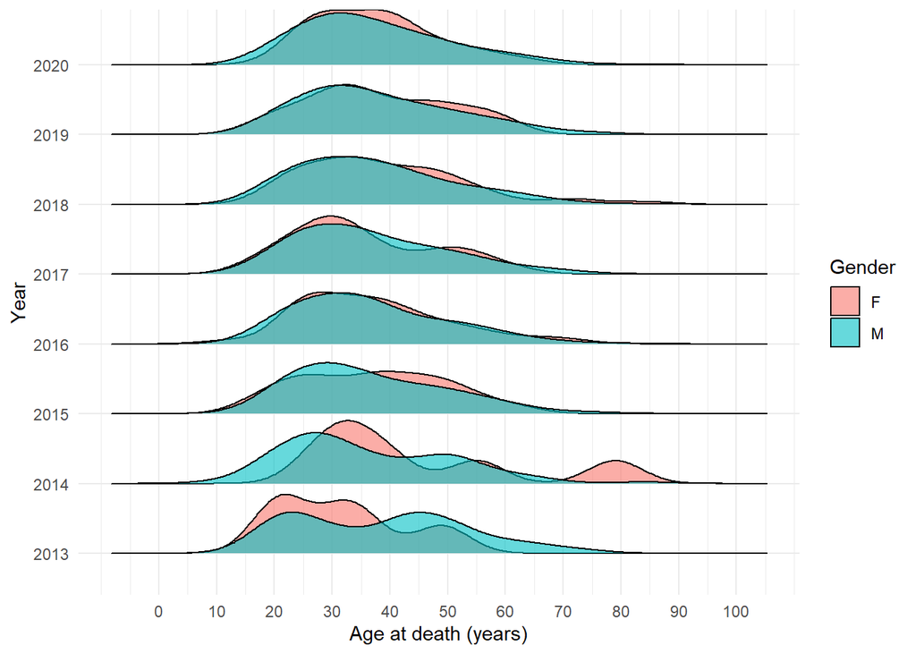

```r
data %>%
  filter(Gender %in% c("M", "F", NA)) %>%
  filter(!is.na(Year)) %>%
  ggplot(aes(x = Age,
             y = factor(Year),
             fill = Gender)) +
  geom_density_ridges(alpha = 0.6,
                      scale = 0.9)  +
  theme_ridges(font_size = 10) +
  scale_x_continuous(breaks = seq(0, 100, 10),
                     labels = seq(0, 100, 10)) +
  xlab("Age at death (years)") +
  ylab("Year") +
  theme_minimal()
```

## Trends in states

I made a simple plot to explore the trends in the states over time.

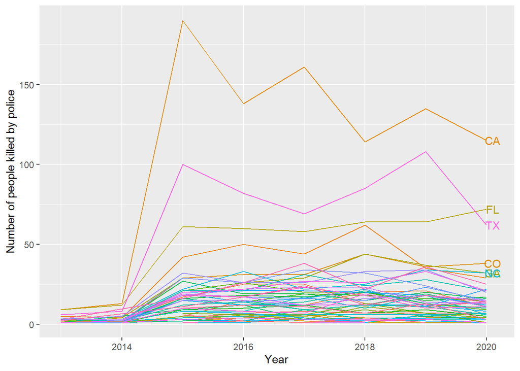

```r
n_over_time_by_state <- data %>%
  group_by(State, Year) %>%
  tally() %>%
  ungroup()

ggplot(n_over_time_by_state,
       aes(Year, n, colour = State)) +
  geom_line() +
  geom_text(data = n_over_time_by_state[n_over_time_by_state$n > 30 & n_over_time_by_state$Year == 2020,],
           aes(label = State,
               x = 2020.1,
               y = n,
               colour = State)) +
  ylab("Number of people killed by police") +
  xlab("Year") +
  theme(legend.position="none")
```

California, Florida, Texas, and Colorado generally had the most killed. But to nuance these data I wanted to see the data per capita.

### State populations

I was not able to find yearly state population data from a credible source, so I resorted to just use data from 2020. But first I need to scrape the data.

#### Scraping state population data

```r
library(rvest)
url <- read_html("https://www.infoplease.com/us/states/state-population-by-rank")
state_pop <- url %>%
        html_nodes("table") %>%
        html_table()  # result is a list
state_pop <- do.call(cbind,unlist(state_pop, recursive = FALSE)) # returns the data as a data frame

str(state_pop)
```

```
##  chr [1:52, 1:4] "1" "2" "3" "4" "5" "6" "7" "8" "9" "10" "11" "12" "13" ...
##  - attr(*, "dimnames")=List of 2
##   ..$ : NULL
##   ..$ : chr [1:4] "Rank" "State" "2020 Census" "Percent of Total"
```

```r
state_pop <- as_tibble(state_pop)  %>%
    mutate(Rank = as.numeric(Rank))  %>% # make Rank numeric
  rename(Population = "2020 Census")  %>% # renaming 2020 Census to Population
  mutate(Population = as.numeric(gsub(",","", Population)))  %>% # removing commas and makiong Population numeric
  mutate(State = state.abb[match(State, state.name)]) # renaming state names to state abbreviations

str(state_pop)
```

```
## tibble [52 × 4] (S3: tbl_df/tbl/data.frame)
##  $ Rank            : num [1:52] 1 2 3 4 5 6 7 8 9 10 ...
##  $ State           : chr [1:52] "CA" "TX" "FL" "NY" ...
##  $ Population      : num [1:52] 39538223 29145505 21538187 20201249 13002700 ...
##  $ Percent of Total: chr [1:52] "11.91%" "8.74%" "6.47%" "5.86%" ...
```

### Looking at 2020 data

Now I can look at the data for 2020

```r
pk2020 <- data %>% # police killing data for 2020
  filter(Year %in% c("2020", NA)) %>%
  filter(!is.na(Year)) %>%
  group_by(State) %>%
  tally() %>%
  ungroup()

pk2020_by_state_pop <- as_tibble(merge(pk2020, state_pop[c("Population", "State")], by="State")) %>% # merging police killing data and state population data
  transform(Killings_per_capita = n / Population) %>%
  arrange(desc(Killings_per_capita))

top10_states <- pk2020_by_state_pop %>% # look at the top 10 states for killings per capita
  slice(1:10)

top10_states
```

```
##    State  n Population Killings_per_capita
## 1     AK  7     733391        9.544704e-06
## 2     NV 22    3104614        7.086227e-06
## 3     CO 38    5773714        6.581552e-06
## 4     MT  7    1084225        6.456224e-06
## 5     NM 12    2117522        5.667001e-06
## 6     OK 20    3959353        5.051330e-06
## 7     UT 14    3205958        4.366869e-06
## 8     AZ 29    7151502        4.055092e-06
## 9     ND  3     779094        3.850626e-06
## 10    KY 17    4505836        3.772885e-06
```